# Business Task Statement _ Capstone Cyclist

Josef

2023-09-22

## Business Task

### Scenario

- Since 2016, Cyclistic developed a successful bike-share offering.
- the program has grown to a fleet of 5,824 bicycles that are geotracked and locked into a network of 692 stations across Chicago.
- Customers who purchase single-ride or full-day passes are referred to as casual riders. Customers who purchase annual memberships are Cyclistic members
- Financial analysts have concluded, that annual memberships are much more profitable than casual riders
- Marketing manager Moreno believes that maximizing the number of annual members will be key to future growth

### Business Goal

- **Design marketing strategies aimed at converting casual riders into annual members**

### Questions to answer

1. How do annual members and casual riders use Cyclistic bikes differently?
2. Why would casual riders buy Cyclistic annual memberships?
3. How can Cyclistic use digital media to influence casual riders to become members?

## Key Question

- **How do annual members and casual riders use Cyclistic bikes differently?**

## Data Set

The data we use is from 01.01.2019 to 31.12.2019. It covers all bike rides in this period undertaken by subscribers or casual users. The following information can be found in the dataset: * **Trip ID** Unique ID for each ride * **Start and end time of each trip** Given in date-time-format (DD/MM/YYYY - HH:MM:SS) * **Start station and end station, ID and Name** Each station has a unique numeric ID assigned to as well as a unique name * **bike ID** each bike has a unique ID * **user type** categorizes the client in subscriber and casual user * **gender and birth year** gender and birth year of the client

## Data Cleaning and Merging

To obtain the data for the whole year 2019, I had to use for different csv-files, that contain the same columns, but follow different naming conventions. The first step of the data cleaning process is therefore to define column names and ensure consistency of the column naming across all four tables.

```r
##Libraries needed:
library(tidyverse)
```

```r
library(ggplot2)
library(lubridate)
```

Uploading Divvy datasets (csv files)

```r
setwd("\\\\wsl.localhost/Ubuntu/home/josef/code/josefperera/Capstone Project/Data/csv")
```

```r
df2<- read_csv("Divvy_Trips_2019_Q2.csv")
df3 <- read_csv("Divvy_Trips_2019_Q3.csv")
df4 <- read_csv("Divvy_Trips_2019_Q4.csv")
df1 <- read_csv("Divvy_Trips_2019_Q1.csv")
```

Comparing column names across all four data sets to ensure consistency in naming conventions

```r
colnames(df1)
```

```
##  [1] "trip_id"           "start_time"        "end_time"
##  [4] "bikeid"            "tripduration"      "from_station_id"
##  [7] "from_station_name" "to_station_id"     "to_station_name"
## [10] "usertype"          "gender"            "birthyear"
```

```r
colnames(df2)
```

```
##  [1] "01 - Rental Details Rental ID"
##  [2] "01 - Rental Details Local Start Time"
##  [3] "01 - Rental Details Local End Time"
##  [4] "01 - Rental Details Bike ID"
##  [5] "01 - Rental Details Duration In Seconds Uncapped"
##  [6] "03 - Rental Start Station ID"
##  [7] "03 - Rental Start Station Name"
##  [8] "02 - Rental End Station ID"
##  [9] "02 - Rental End Station Name"
## [10] "User Type"
## [11] "Member Gender"
## [12] "05 - Member Details Member Birthday Year"
```

```r
colnames(df3)
```

```
##  [1] "trip_id"           "start_time"        "end_time"
##  [4] "bikeid"            "tripduration"      "from_station_id"
##  [7] "from_station_name" "to_station_id"     "to_station_name"
## [10] "usertype"          "gender"            "birthyear"
```

```r
colnames(df4)
```

```
##  [1] "trip_id"           "start_time"        "end_time"
##  [4] "bikeid"            "tripduration"      "from_station_id"
##  [7] "from_station_name" "to_station_id"     "to_station_name"
## [10] "usertype"          "gender"            "birthyear"
```

Renaming column names. In the case of the 2019 data, this was quite easy, since only the table of Quarter 2 used different column names. The tables for the other quarters were named consistently.

```r
df2<- df2 %>% rename("trip_id" = "01 - Rental Details Rental ID",
                     "start_time"="01 - Rental Details Local Start Time",
                     "end_time"="01 - Rental Details Local End Time",
                     "bikeid"="01 - Rental Details Bike ID",
                     "tripduration"="01 - Rental Details Duration In Seconds Uncapped",
                     "from_station_id"="03 - Rental Start Station ID",
                     "from_station_name"="03 - Rental Start Station Name",
                     "to_station_id"="02 - Rental End Station ID",
                     "to_station_name"="02 - Rental End Station Name",
                     "usertype"="User Type",
                     "gender"="Member Gender",
                     "birthyear"="05 - Member Details Member Birthday Year")
```

In the next step, I checked for incongruities in the naming of categories across the tables using the str()- and unique()-function

Luckily, everything looks fine here. So finally, we can merge all four tables into one single table!

```r
df <- bind_rows(df1, df2, df3, df4)
```

## Data Analysis

### Summary Statistics

Number of rows

```r
nrow(df)
```

```
## [1] 3818004
```

Dimension

```r
dim(df)
```

```
## [1] 3818004      12
```

Structure of the data

```r
str(df)
```

```
## spc_tbl_ [3,818,004 × 12] (S3: spec_tbl_df/tbl_df/tbl/data.frame)
##  $ trip_id          : num [1:3818004] 21742443 21742444 21742445 21742446 21742447 ...
##  $ start_time       : POSIXct[1:3818004], format: "2019-01-01 00:04:37" "2019-01-01 00:08:13" ...
##  $ end_time         : POSIXct[1:3818004], format: "2019-01-01 00:11:07" "2019-01-01 00:15:34" ...
##  $ bikeid           : num [1:3818004] 2167 4386 1524 252 1170 ...
##  $ tripduration     : num [1:3818004] 390 441 829 1783 364 ...
##  $ from_station_id  : num [1:3818004] 199 44 15 123 173 98 98 211 150 268 ...
##  $ from_station_name: chr [1:3818004] "Wabash Ave & Grand Ave" "State St & Randolph St" "Racine Ave & 18th St" "California Ave & Milwaukee Ave" ...
##  $ to_station_id    : num [1:3818004] 84 624 644 176 35 49 49 142 148 141 ...
##  $ to_station_name  : chr [1:3818004] "Milwaukee Ave & Grand Ave" "Dearborn St & Van Buren St (*)" "Western Ave & Fillmore St (*)" "Clark St & Elm St" ...
##  $ usertype         : chr [1:3818004] "Subscriber" "Subscriber" "Subscriber" "Subscriber" ...
##  $ gender           : chr [1:3818004] "Male" "Female" "Female" "Male" ...
##  $ birthyear        : num [1:3818004] 1989 1990 1994 1993 1994 ...
##  - attr(*, "spec")=
##   .. cols(
##   ..   trip_id = col_double(),
##   ..   start_time = col_datetime(format = ""),
##   ..   end_time = col_datetime(format = ""),
##   ..   bikeid = col_double(),
##   ..   tripduration = col_number(),
##   ..   from_station_id = col_double(),
##   ..   from_station_name = col_character(),
##   ..   to_station_id = col_double(),
##   ..   to_station_name = col_character(),
##   ..   usertype = col_character(),
##   ..   gender = col_character(),
##   ..   birthyear = col_double()
##   .. )
##  - attr(*, "problems")=<externalptr>
```

The table consists of 6 numeric columns, 4 character columns and 2 columns with date-time information (class POSIXct)

```r
summary(df)
```

```
##     trip_id           start_time
##  Min.   :21742443   Min.   :2019-01-01 00:04:37.00
##  1st Qu.:22873787   1st Qu.:2019-05-29 15:49:26.50
##  Median :23962320   Median :2019-07-25 17:50:54.00
##  Mean   :23915629   Mean   :2019-07-19 21:47:37.11
##  3rd Qu.:24963703   3rd Qu.:2019-09-15 06:48:05.75
##  Max.   :25962904   Max.   :2019-12-31 23:57:17.00
##
##     end_time                          bikeid      tripduration
##  Min.   :2019-01-01 00:11:07.00   Min.   :   1   Min.   :      61
##  1st Qu.:2019-05-29 16:09:28.25   1st Qu.:1727   1st Qu.:     411
##  Median :2019-07-25 18:12:23.00   Median :3451   Median :     709
##  Mean   :2019-07-19 22:11:47.56   Mean   :3380   Mean   :    1450
##  3rd Qu.:2019-09-15 08:30:13.25   3rd Qu.:5046   3rd Qu.:    1283
##  Max.   :2020-01-21 13:54:35.00   Max.   :6946   Max.   :10628400
##
##  from_station_id from_station_name  to_station_id   to_station_name
##  Min.   :  1.0   Length:3818004     Min.   :  1.0   Length:3818004
##  1st Qu.: 77.0   Class :character   1st Qu.: 77.0   Class :character
##  Median :174.0   Mode  :character   Median :174.0   Mode  :character
##  Mean   :201.7                      Mean   :202.6
##  3rd Qu.:289.0                      3rd Qu.:291.0
##  Max.   :673.0                      Max.   :673.0
##
##    usertype            gender            birthyear
##  Length:3818004     Length:3818004     Min.   :1759
##  Class :character   Class :character   1st Qu.:1979
##  Mode  :character   Mode  :character   Median :1987
##                                        Mean   :1984
##                                        3rd Qu.:1992
##                                        Max.   :2014
##                                        NA's   :538751
```

The summary table gives us a first idea of the distribution of the data, the means, outliers and missing data.

```r
df$date <- as.Date(df$start_time, format="%d/%m/%Y")
df$month <- format(as.Date(df$date),"%m")
df$day <- format(as.Date(df$date),"%d")
df$weekday <- format(as.Date(df$date),"%A")
```

Time of the day

```r
df$time <- format(df$start_time, format = "%H")
```

After having extracted the hour, we can attribute hours to time ranges categorized as “Night : 12am - 06am” “Morning : 06am - 12am”, “Afternoon : 12pm - 6pm”, “Evening : 6pm - 12am”.

Before doing so, I have to transform df$dayrange and df$time to numeric class.

```r
# check for the class of the newly created columns:
sapply( df, class)
```

```
## $trip_id
## [1] "numeric"
##
## $start_time
## [1] "POSIXct" "POSIXt"
##
## $end_time
## [1] "POSIXct" "POSIXt"
##
## $bikeid
## [1] "numeric"
##
## $tripduration
## [1] "numeric"
##
## $from_station_id
## [1] "numeric"
##
## $from_station_name
## [1] "character"
##
## $to_station_id
## [1] "numeric"
##
## $to_station_name
## [1] "character"
##
## $usertype
## [1] "character"
##
## $gender
## [1] "character"
##
## $birthyear
## [1] "numeric"
##
## $date
## [1] "Date"
##
## $month
## [1] "character"
##
## $day
## [1] "character"
##
## $weekday
## [1] "character"
##
## $time
## [1] "character"
```

```r
df$time <- as.numeric(as.character(df$time))
```

Now I can categorize the time in day-range categories:

```r
cut_points <- c(0, 6, 12, 18, 24)
labels <- c("Night", "Morning", "Afternoon", "Evening")
df$dayrange <- cut(df$time, cut_points, labels = labels, right = FALSE)
```

### Adding Ride length

Since ride duration is only given in seconds, I create another column, that gives me the duration of a ride in minutes.

```r
df$ride_length <- difftime(df$end_time, df$start_time)
str(df)
```

```
## spc_tbl_ [3,818,004 × 19] (S3: spec_tbl_df/tbl_df/tbl/data.frame)
##  $ trip_id          : num [1:3818004] 21742443 21742444 21742445 21742446 21742447 ...
##  $ start_time       : POSIXct[1:3818004], format: "2019-01-01 00:04:37" "2019-01-01 00:08:13" ...
##  $ end_time         : POSIXct[1:3818004], format: "2019-01-01 00:11:07" "2019-01-01 00:15:34" ...
##  $ bikeid           : num [1:3818004] 2167 4386 1524 252 1170 ...
##  $ tripduration     : num [1:3818004] 390 441 829 1783 364 ...
##  $ from_station_id  : num [1:3818004] 199 44 15 123 173 98 98 211 150 268 ...
##  $ from_station_name: chr [1:3818004] "Wabash Ave & Grand Ave" "State St & Randolph St" "Racine Ave & 18th St" "California Ave & Milwaukee Ave" ...
##  $ to_station_id    : num [1:3818004] 84 624 644 176 35 49 49 142 148 141 ...
##  $ to_station_name  : chr [1:3818004] "Milwaukee Ave & Grand Ave" "Dearborn St & Van Buren St (*)" "Western Ave & Fillmore St (*)" "Clark St & Elm St" ...
##  $ usertype         : chr [1:3818004] "Subscriber" "Subscriber" "Subscriber" "Subscriber" ...
##  $ gender           : chr [1:3818004] "Male" "Female" "Female" "Male" ...
##  $ birthyear        : num [1:3818004] 1989 1990 1994 1993 1994 ...
##  $ date             : Date[1:3818004], format: "2019-01-01" "2019-01-01" ...
##  $ month            : chr [1:3818004] "01" "01" "01" "01" ...
##  $ day              : chr [1:3818004] "01" "01" "01" "01" ...
##  $ weekday          : chr [1:3818004] "Dienstag" "Dienstag" "Dienstag" "Dienstag" ...
##  $ time             : num [1:3818004] 0 0 0 0 0 0 0 0 0 0 ...
##  $ dayrange         : Factor w/ 4 levels "Night","Morning",..: 1 1 1 1 1 1 1 1 1 1 ...
##  $ ride_length      : 'difftime' num [1:3818004] 6.5 7.35 13.8166666666667 29.7166666666667 ...
##   ..- attr(*, "units")= chr "mins"
##  - attr(*, "spec")=
##   .. cols(
##   ..   trip_id = col_double(),
##   ..   start_time = col_datetime(format = ""),
##   ..   end_time = col_datetime(format = ""),
##   ..   bikeid = col_double(),
##   ..   tripduration = col_number(),
##   ..   from_station_id = col_double(),
##   ..   from_station_name = col_character(),
##   ..   to_station_id = col_double(),
##   ..   to_station_name = col_character(),
##   ..   usertype = col_character(),
##   ..   gender = col_character(),
##   ..   birthyear = col_double()
##   .. )
##  - attr(*, "problems")=<externalptr>
```

```r
is.difftime(df$ride_length)
```

```
## [1] TRUE
```

```r
df$ride_length <- as.numeric(as.character(df$ride_length))
```

```r
summary(df$birthyear)
```

```
##    Min. 1st Qu.  Median    Mean 3rd Qu.    Max.    NA's
##    1759    1979    1987    1984    1992    2014  538751
```

```r
mean(is.na(df$birthyear))
```

```
## [1] 0.141108
```

```r
mean(is.na(df$gender))
```

```
## [1] 0.1464655
```

Based on the information, I would like to develop a column with age brackets in order to determine if there are age-specific differences in using the offer of Bicyclist. At first, I will create a column ‘Age’

```r
df$age <- (2019-df$birthyear)
summary(df$age)
```

```
##    Min. 1st Qu.  Median    Mean 3rd Qu.    Max.    NA's
##     5.0    27.0    32.0    34.9    40.0   260.0  538751
```

```r
df1 <-df[!(df$age < 260),]
summary(df1$age)
```

```
##    Min. 1st Qu.  Median    Mean 3rd Qu.    Max.    NA's
##     260     260     260     260     260     260  538751
```

I now can attribute age to a age group. I use the common marketing age grouping:

*18-24* 25-34 *35-44* 45-54 *55-64* 65+

```r
age_brackets <- c(0,18, 25, 35, 45, 55, 64, Inf)
labels_age <- c("0-17 y.o.", "18-24 y.o.", "25-34 y.o.", "35-44 y.o.", "45-54 y.o.", "55-64 y.o.", ">=65 y.o.")
df$age_bracket <- cut(df$age, age_brackets, labels_age, right=FALSE)
```

Checking the new column, I realize that there are trips with negative time values. Also, there a trips ending at the Headquarter, which are probably for maintenance / repair. There are also rides that last several days. In order to focus only on daily use cases, I exclude all rides that last longer than 12 hours (720 min). After discovering outliers in the age-column (a datapoint with age = 260 years), I also exclude all data points with individuals older than 100 years to ensure that the age mean is not distorted by outliers. I therefore create a 2nd data frame that excludes these entries. I make sure, that incomplete datasets (missing information on gender and age) remain within the new data frame.

```r
df_v2 <- df[!(df$to_station_name == "HQ QR" | df$ride_length<0 |
                (!is.na(df$age) & df$age >100) |df$ride_length>720),]
```

#Visualization and Analysis

Let’s first check for the population characteristics of subscribers and casual customers.

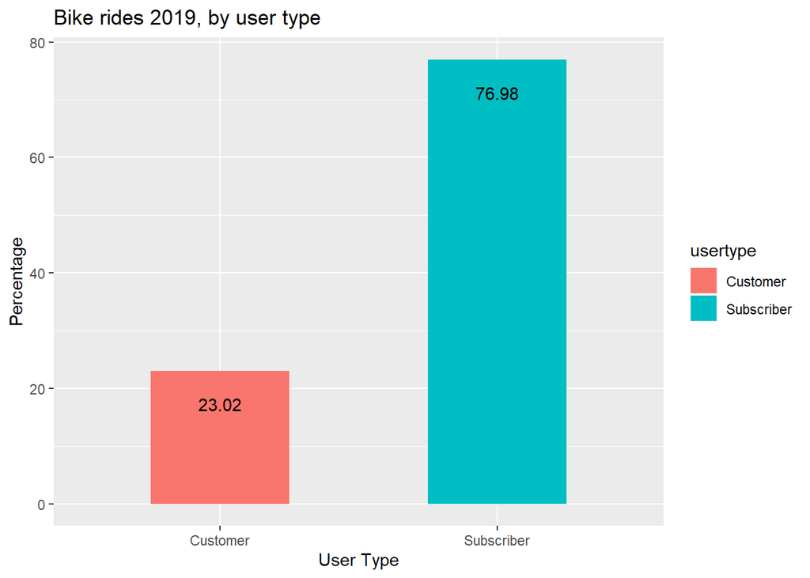

```r
df_v2 %>% group_by(usertype) %>% summarise(total = n()) %>%
  mutate(percentage = round(total/sum(total)*100,2)) %>%
  ggplot(mapping=aes(x= usertype, y=percentage, fill=usertype))+
  geom_col(width=0.5) +
  labs(x="User Type", y= "Percentage", title="Bike rides 2019, by user type") +
  geom_text(aes(label = percentage), vjust = 3)
```

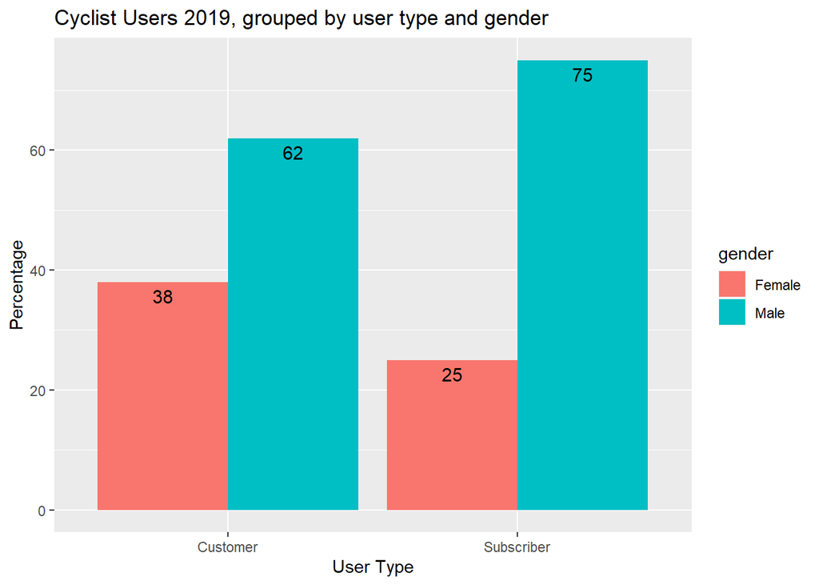

```r
df_v2 %>%  drop_na(gender) %>% group_by(usertype, gender) %>% summarise(total=n()) %>%
  mutate(Percentage = round(total/sum(total)*100)) %>%
  ggplot(mapping = aes(x=usertype, y = Percentage, fill = gender))+
  geom_col(position = "dodge")+ labs(x = "User Type",
  title="Cyclist Users 2019, grouped by user type and gender") +
  geom_text(aes(label = Percentage), vjust = 1.5, size = 4,position = position_dodge(width = 0.9))
```

We can see, that subscibers and casual customers differ slightly when it comes to gender composition. Female casual customers represent almost 40% of their user type class, while female subscribers represent only 25% of their user type class.

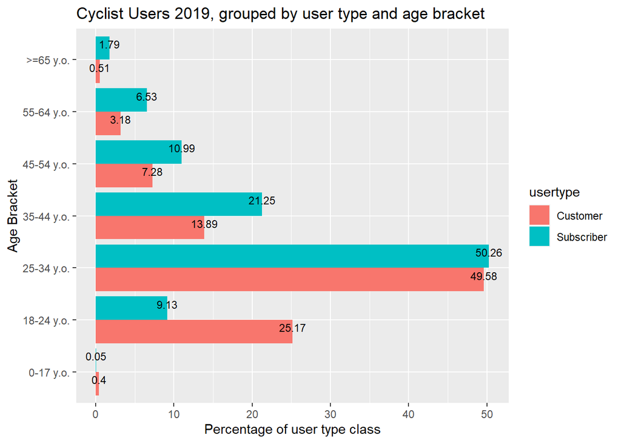

```r
df_v2 %>%  drop_na(age_bracket) %>%  group_by(usertype, age_bracket) %>% summarise(total=n()) %>%
  mutate(Percentage = round(total/sum(total)*100,2)) %>%
  ggplot(mapping = aes(x=age_bracket, y = Percentage, fill = usertype))+
  geom_col(position = "dodge")+ labs(x = "Age Bracket",
  y= "Percentage of user type class",
  title="Cyclist Users 2019, grouped by user type and age bracket") +
  geom_text(aes(label = Percentage), vjust = 0, size = 3,
            position = position_dodge(width = 0.9))+coord_flip()
```

Roughly half of Cyclist subscribers and casual users are in the age bracket between 25 to 34 years. Differences in age structure between the user types are evident in the age bracket 18 to 24 years, where casual customers are almost 3 times more than subscribers. However, cyclist subscribers are significantly more represented in the higher age brackets (35 years onwards). In conclusion, we can assume, that casual customers are younger as well as slightly less male. Although, I need to mention, that we don’t know how to impute the missing age and gender data and therefore cannot be sure, that omitting the missing values resulted in a biased data set. In order to properly interpret the population characteristics, we need further information on the missing data.

## When do casual customers and subscribers use the bike?

Lets take a look at the circumstances under which subscribers and casual users use the bike. First of all, throughout the year:

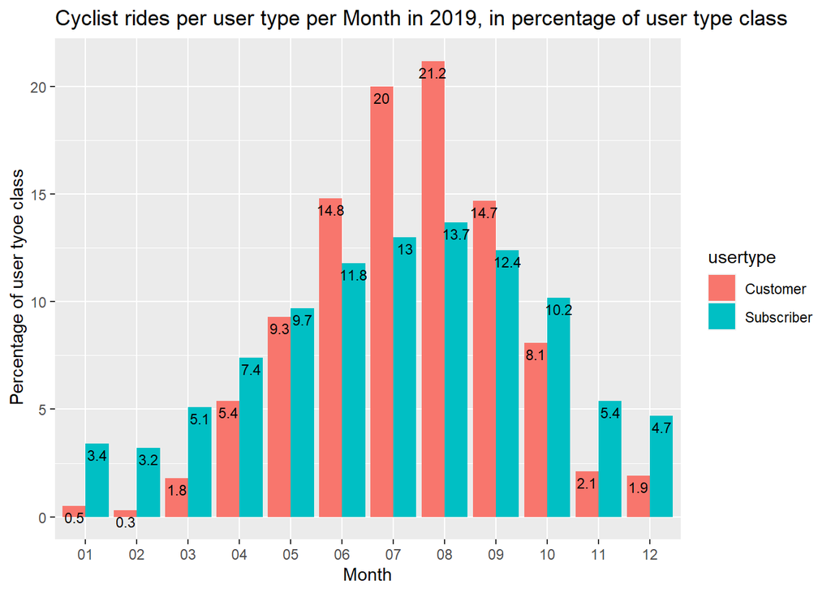

```r
df_v2 %>% group_by(usertype, month) %>% summarise(number_of_rides = n()) %>%
  mutate(Percentage = round(number_of_rides/sum(number_of_rides)*100,1)) %>%
  ggplot(mapping= aes(x= month, y= Percentage, fill = usertype)) +
  geom_col(position = "dodge") +
  labs(x= "Month", y = " Percentage of user tyoe class",
       title = "Cyclist rides per user type per Month in 2019, in percentage of user type class" )+
  geom_text(aes(label= Percentage), vjust=1.5, size = 3,
            position = position_dodge(width = 0.9))
```

In both user groups we can observe that rides increase throughout spring to peak during the summer months and to decrease in the same manner during autumn. The difference between summer months and winter months in demand for rides is much stronger within the group of casual customers, while subscriber usage throughout the year is slightly smoother. The smoothness of the subscriber curve (in comparison to the demand of casual customers) can be explained through the fact, that they use bikes more regularly in their daily life for things such as daily commute to work, or also as an alternative to public transports or motorized vehicles to move across town to do errands. Casual customers demand peaking during the summer months might be hinting to a rather leisure-motivated use of Cyclist bikes. Let’s have a look at ride demand throughout the week, maybe this could let us understand better the differences in demand between Customers and Subscribers.

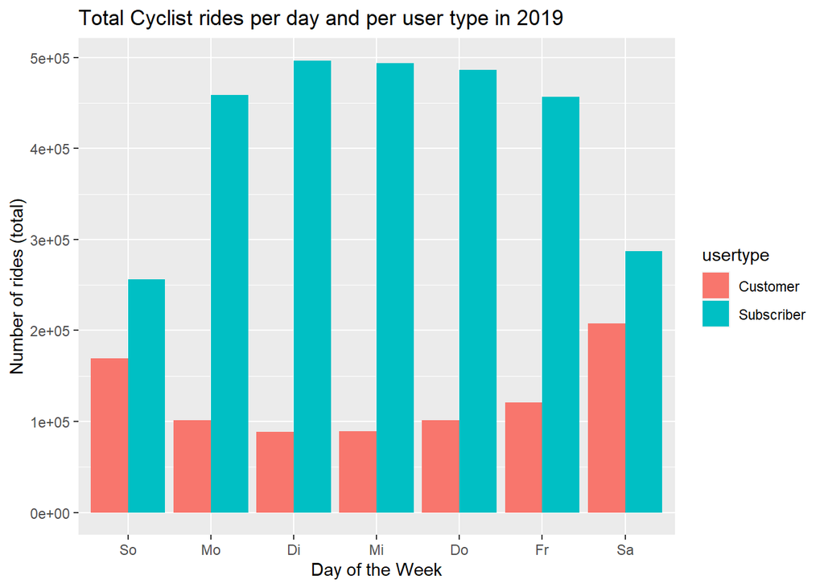

```r
df_v2 %>% mutate(weekday = wday(df_v2$start_time, label = TRUE )) %>%
  group_by(usertype, weekday) %>%
  summarise(number_of_rides = n(),average_duration = mean(ride_length)) %>%
  arrange(usertype, weekday) %>%
  ggplot(mapping = aes(x= weekday, y= number_of_rides, fill = usertype)) +
  geom_col(position = "dodge") + labs(x = "Day of the Week",
  y = "Number of rides (total)",
  title= "Total Cyclist rides per day and per user type in 2019")
```

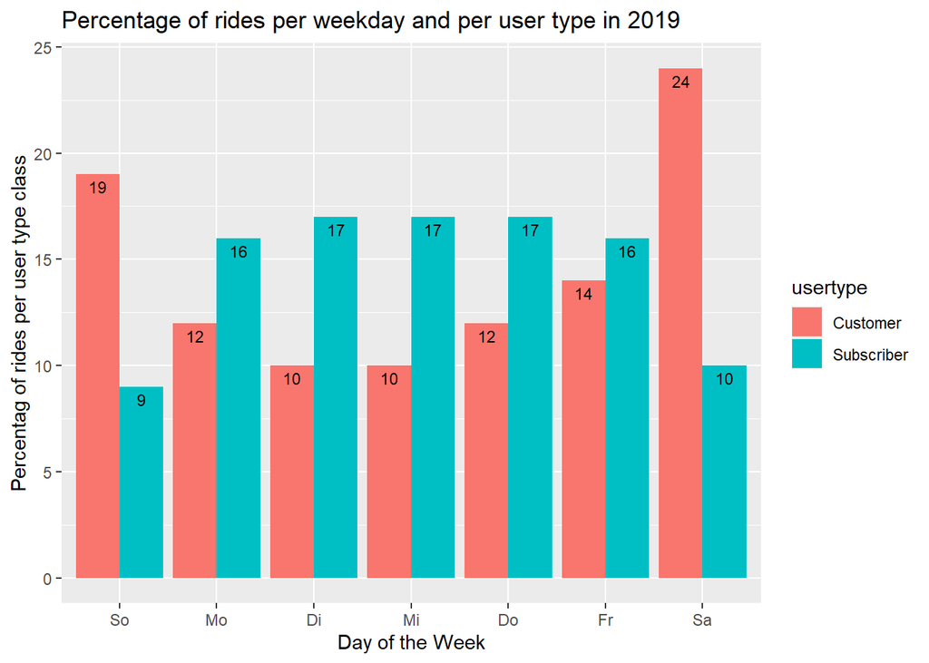

```r
df_v2 %>% mutate(weekday = wday(df_v2$start_time, label = TRUE )) %>%
  group_by(usertype, weekday) %>%
  summarise(total = n()) %>% mutate(Percentage = round(total/sum(total)*100)) %>%
  arrange(usertype, weekday) %>%
  ggplot(mapping = aes(x= weekday, y= Percentage, fill = usertype)) +
  geom_col(position = "dodge") + labs(x = "Day of the Week",
  y = "Percentag of rides per user type class",
  title= "Percentage of rides per weekday and per user type in 2019") +
  geom_text(aes(label= Percentage), vjust=1.5, size = 3,
            position = position_dodge(width = 0.9))
```

Demand for rides for the two usertypes is almost “complementary”. While subscribers demand Cyclist bikes a lot during the week (Monday to Friday) and reduce their demand at the weekend almost by half, casual customers demand for bike rides peaks during Sundays and Saturdays. This would be a strong argument for the theory, that casual customers use bikes more likely for leisure reasons than subscribers, and that subscribers rely on Cyclist bikes a lot during the week to commute to work. Lets have a look at daytime variations, this might tell us even more about the different demand patterns.

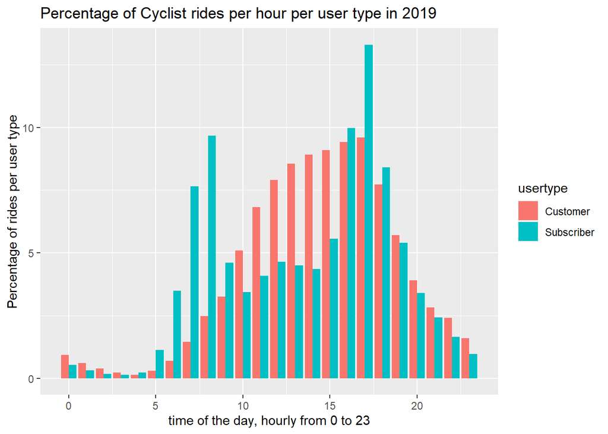

```r
df_v2 %>% group_by(usertype,time) %>% summarize(count = n()) %>%
  mutate(Percentage= round(count/sum(count)*100,2)) %>%
    ggplot(aes(x=time, y=Percentage, fill=usertype)) +
  geom_col(position="dodge") +
  labs(x = "time of the day, hourly from 0 to 23",
         y = "Percentage of rides per user type",
         title = "Percentage of Cyclist rides per hour per user type in 2019")
```

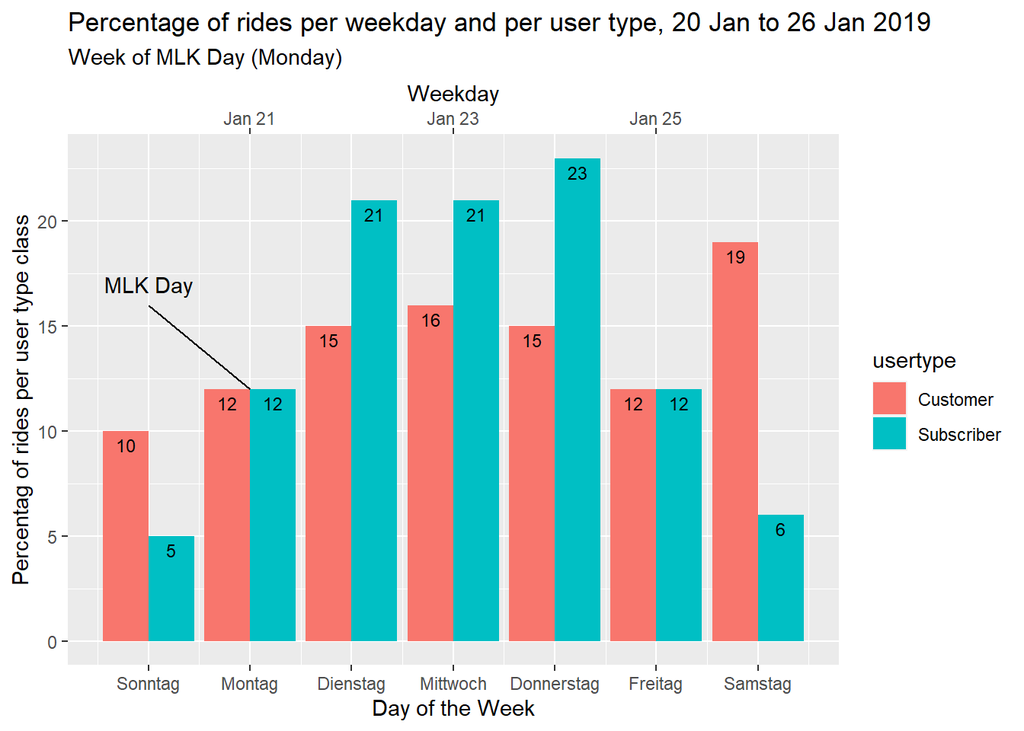

```r
df_v2 %>% mutate(weekday = wday(df_v2$start_time, label = TRUE )) %>%
  filter(between(date, as.Date('2019-01-20'), as.Date('2019-01-26'))) %>% group_by(usertype, date) %>%
  summarise(total = n()) %>% mutate(Percentage = round(total/sum(total)*100)) %>%
  ggplot(mapping = aes(x= date, y= Percentage, fill = usertype)) +
  geom_col(position = "dodge") + labs(x = "Day of the Week",
  y = "Percentag of rides per user type class",
  title= "Percentage of rides per weekday and per user type, 20 Jan to 26 Jan 2019",
  subtitle = "Week of MLK Day (Monday)") +
  geom_text(aes(label= Percentage), vjust=1.5, size = 3,
            position = position_dodge(width = 0.9)) +
  scale_x_date(sec.axis = sec_axis(~., name = "Weekday"),date_breaks = "1 day",
  date_labels = "%A" )+
  annotate(geom = "segment", x = as.Date('2019-01-20'), y = 16,
           xend = as.Date('2019-01-21'), yend = 12)+
  annotate(geom = "Text", x = as.Date('2019-01-20'), y = 17, label = "MLK Day", hjust = "center")
```

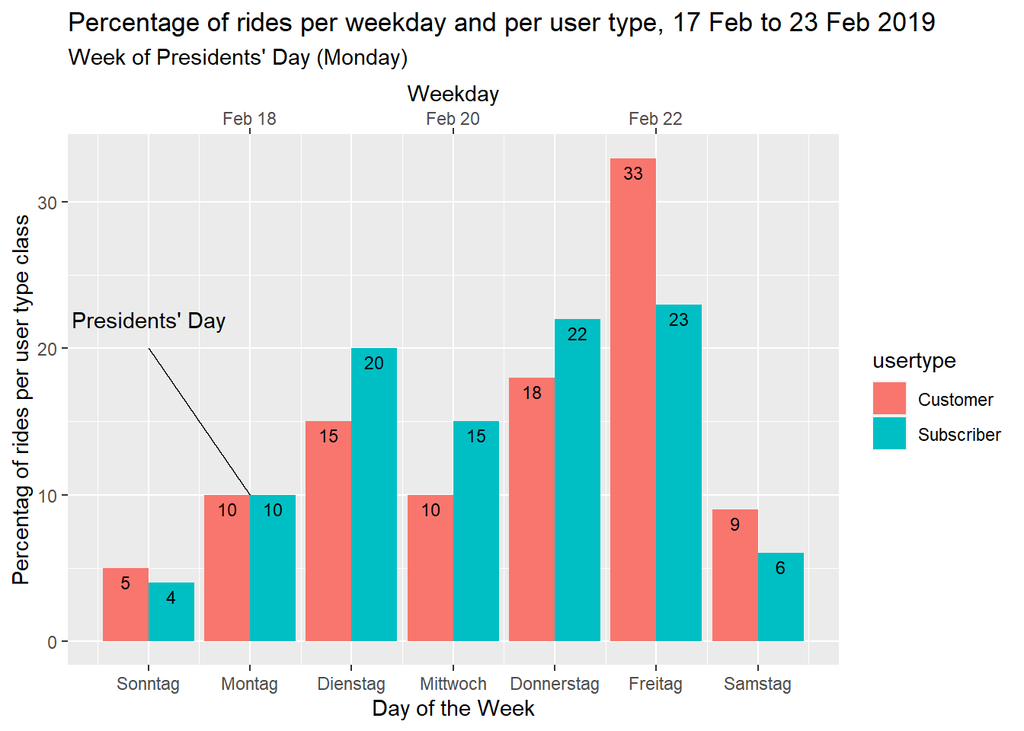

```r
df_v2 %>% mutate(weekday = wday(df_v2$start_time, label = TRUE )) %>%
  filter(between(date, as.Date('2019-02-17'), as.Date('2019-02-23'))) %>% group_by(usertype, date) %>%
  summarise(total = n()) %>% mutate(Percentage = round(total/sum(total)*100)) %>%
  ggplot(mapping = aes(x= date, y= Percentage, fill = usertype)) +
  geom_col(position = "dodge") + labs(x = "Day of the Week",
  y = "Percentag of rides per user type class",
  title= "Percentage of rides per weekday and per user type, 17 Feb to 23 Feb 2019",
  subtitle = "Week of Presidents' Day (Monday)") +
  geom_text(aes(label= Percentage), vjust=1.5, size = 3,
            position = position_dodge(width = 0.9))+
  scale_x_date(sec.axis = sec_axis(~., name = "Weekday"),date_breaks = "1 day",
  date_labels = "%A" ) +
  annotate(geom = "segment", x = as.Date('2019-02-17'), y = 20,
           xend = as.Date('2019-02-18'), yend = 10)+
  annotate(geom = "Text", x = as.Date('2019-02-17'), y = 22, label = "Presidents' Day", hjust = "center")
```

On Presidents’ Day we can see a similar pattern: relative demand for bike rides of subscribers is lower than usually and is at par with the demand-percentage from casual customers. It is important to notice that in the week of MLK Day and Presients’ Day, casual customer demand is NOT peaking on the holiday, which would refute my theory that casual customers are mostly visitors spending the holiday to discover the city on bike. Let’s fast forward to lovely springtime and check the next big holiday, Memorial Day.

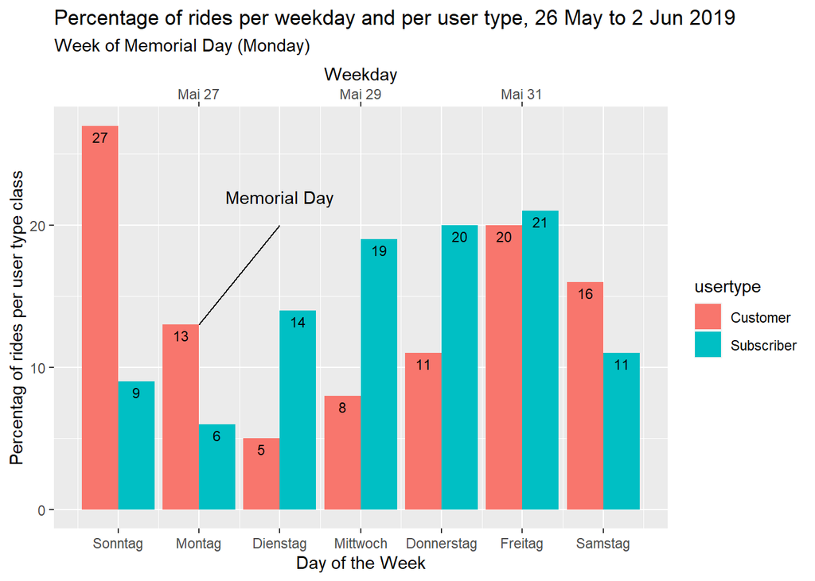

```r
df_v2 %>% mutate(weekday = wday(df_v2$start_time, label = TRUE )) %>%
  filter(between(date, as.Date('2019-05-26'), as.Date('2019-06-01'))) %>% group_by(usertype, date) %>%
  summarise(total = n()) %>% mutate(Percentage = round(total/sum(total)*100)) %>%
  ggplot(mapping = aes(x= date, y= Percentage, fill = usertype)) +
  geom_col(position = "dodge") + labs(x = "Day of the Week",
  y = "Percentag of rides per user type class",
  title= "Percentage of rides per weekday and per user type, 26 May to 2 Jun 2019",
  subtitle= "Week of Memorial Day (Monday)") +
  geom_text(aes(label= Percentage), vjust=1.5, size = 3,
            position = position_dodge(width = 0.9))+
  scale_x_date(sec.axis = sec_axis(~., name = "Weekday"),date_breaks = "1 day",
  date_labels = "%A") +
  annotate(geom = "segment", x = as.Date('2019-05-28'), y = 20,
           xend = as.Date('2019-05-27'), yend = 13)+
  annotate(geom = "Text", x = as.Date('2019-05-28'), y = 22, label = "Memorial Day", hjust = "center")
```

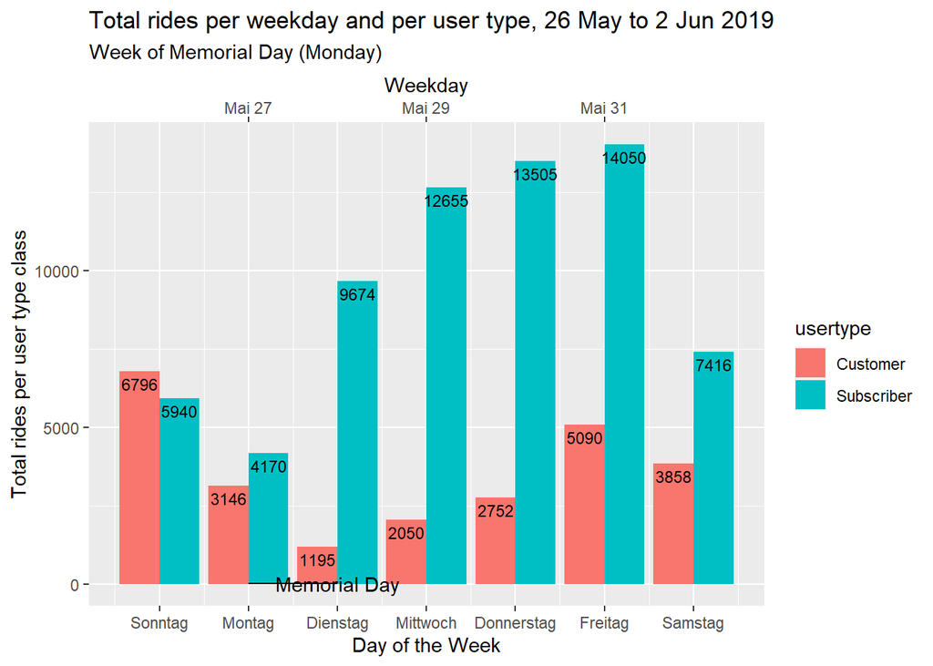

```r
df_v2 %>% mutate(weekday = wday(df_v2$start_time, label = TRUE )) %>%
  filter(between(date, as.Date('2019-05-26'), as.Date('2019-06-01'))) %>% group_by(usertype, date) %>%
  summarise(total = n()) %>% mutate(Percentage = round(total/sum(total)*100)) %>%
  ggplot(mapping = aes(x= date, y= total, fill = usertype)) +
  geom_col(position = "dodge") + labs(x = "Day of the Week",
  y = "Total rides per user type class",
  title= "Total rides per weekday and per user type, 26 May to 2 Jun 2019",
  subtitle= "Week of Memorial Day (Monday)") +
  geom_text(aes(label= total), vjust=1.5, size = 3,
            position = position_dodge(width = 0.9))+
  scale_x_date(sec.axis = sec_axis(~., name = "Weekday"),date_breaks = "1 day",
  date_labels = "%A") +
  annotate(geom = "segment", x = as.Date('2019-05-28'), y = 20,
           xend = as.Date('2019-05-27'), yend = 13)+
  annotate(geom = "Text", x = as.Date('2019-05-28'), y = 22, label = "Memorial Day", hjust = "center")
```

On Memorial Day we can clearly see an unusually high percentage of casual customer demand for a Monday. Looking at the total number of casual customer rides however, we see that overall demand on the holiday was particularly low. Checking the weather of that particual Memorial Day, the National Weather Service tells me “With the 1.92” of rain recorded at Chicago O’Hare, this set a daily record for precipitation for May 27th, as well as making it the wettest Memorial Day on record.” We might have to take into account, that weather is a major factor for bike demand.

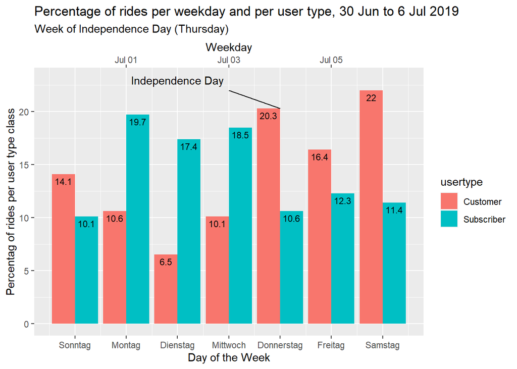

```r
df_v2 %>% mutate(weekday = wday(df_v2$start_time, label = TRUE )) %>%
  filter(between(date, as.Date('2019-06-30'), as.Date('2019-07-06'))) %>% group_by(usertype, date) %>%
  summarise(total = n()) %>% mutate(Percentage = round(total/sum(total)*100,1)) %>%
  ggplot(mapping = aes(x= date, y= Percentage, fill = usertype)) +
  geom_col(position = "dodge") + labs(x = "Day of the Week",
  y = "Percentag of rides per user type class",
  title= "Percentage of rides per weekday and per user type, 30 Jun to 6 Jul 2019",
  subtitle= "Week of Independence Day (Thursday)") +
  geom_text(aes(label= Percentage), vjust=1.5, size = 3,
            position = position_dodge(width = 0.9)) +
  scale_x_date(sec.axis = sec_axis(~., name = "Weekday"),date_breaks = "1 day",
  date_labels = "%A" )+
  annotate(geom = "segment", x = as.Date('2019-07-03'), y = 22,
           xend = as.Date('2019-07-04'), yend = 20.3)+
  annotate(geom = "Text", x = as.Date('2019-07-02'), y = 23, label = "Independence Day", hjust = "center")
```

Similar pattern on the week of Independence Day: The percentage of demand for bikes coming from casual customers spikes on the holiday and stays on a high level on the following days. Another indicator for the hypothesis, that a big percentage of casual customers is due to visitors /tourists. Lets have a look at the total number of rides during that week, grouped by user type:

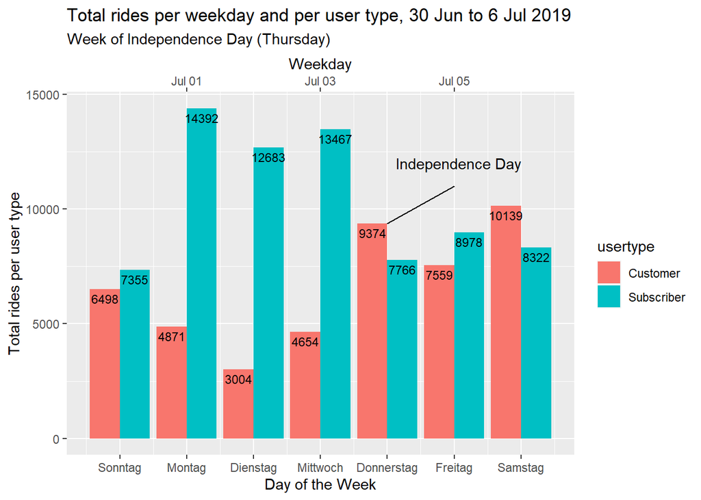

```r
df_v2 %>% mutate(weekday = wday(df_v2$start_time, label = TRUE )) %>%
  filter(between(date, as.Date('2019-06-30'), as.Date('2019-07-06'))) %>% group_by(usertype, date) %>%
  summarise(total = n()) %>% mutate(Percentage = round(total/sum(total)*100,1)) %>%
  ggplot(mapping = aes(x= date, y= total, fill = usertype)) +
  geom_col(position = "dodge") + labs(x = "Day of the Week",
  y = "Total rides per user type",
  title= "Total rides per weekday and per user type, 30 Jun to 6 Jul 2019",
  subtitle= "Week of Independence Day (Thursday)") +
  geom_text(aes(label= total), vjust=1.5, size = 3,
            position = position_dodge(width = 0.9)) +
  scale_x_date(sec.axis = sec_axis(~., name = "Weekday"),date_breaks = "1 day",
  date_labels = "%A" )+
  annotate(geom = "segment", x = as.Date('2019-07-05'), y = 11000,
           xend = as.Date('2019-07-04'), yend = 9374)+
  annotate(geom = "Text", x = as.Date('2019-07-06'), y = 12000, label = "Independence Day", hjust = "right")
```

This confirms the hypothesis: when looking at the total numbers on Thursday, we see that demand from casual customers surpasses demand of subscribers and remains high throughout the weekend.

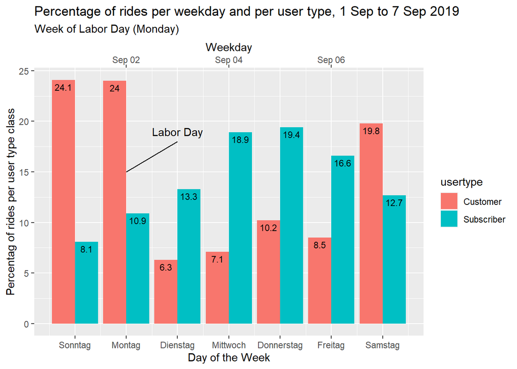

```r
df_v2 %>% mutate(weekday = wday(df_v2$start_time, label = TRUE )) %>%
  filter(between(date, as.Date('2019-09-01'), as.Date('2019-09-07'))) %>% group_by(usertype, date) %>%
  summarise(total = n()) %>% mutate(Percentage = round(total/sum(total)*100,1)) %>%
  ggplot(mapping = aes(x= date, y= Percentage, fill = usertype)) +
  geom_col(position = "dodge") + labs(x = "Day of the Week",
  y = "Percentag of rides per user type class",
  title= "Percentage of rides per weekday and per user type, 1 Sep to 7 Sep 2019",
  subtitle ="Week of Labor Day (Monday)") + geom_text(aes(label= Percentage), vjust=1.5, size = 3,
            position = position_dodge(width = 0.9))+
  scale_x_date(sec.axis = sec_axis(~., name = "Weekday"),date_breaks = "1 day",
  date_labels = "%A" )+
  annotate(geom = "segment", x = as.Date('2019-09-03'), y = 18,
           xend = as.Date('2019-09-02'), yend = 15)+
  annotate(geom = "Text", x = as.Date('2019-09-03'), y = 19, label = "Labor Day", hjust = "center")
```

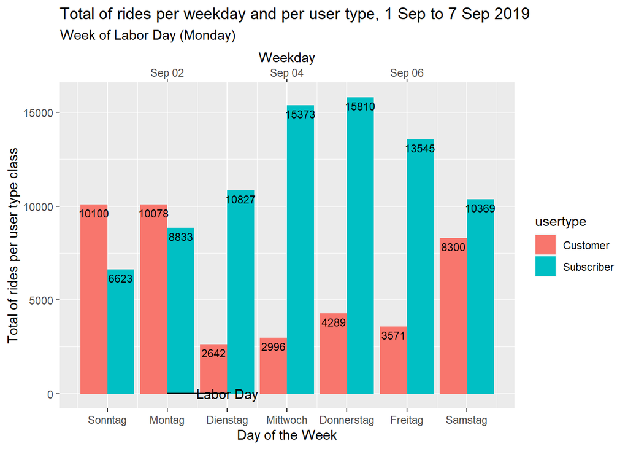

```r
df_v2 %>% mutate(weekday = wday(df_v2$start_time, label = TRUE )) %>%
  filter(between(date, as.Date('2019-09-01'), as.Date('2019-09-07'))) %>% group_by(usertype, date) %>%
  summarise(total = n()) %>% mutate(Percentage = round(total/sum(total)*100,1)) %>%
  ggplot(mapping = aes(x= date, y= total, fill = usertype)) +
  geom_col(position = "dodge") + labs(x = "Day of the Week",
  y = "Total of rides per user type class",
  title= "Total of rides per weekday and per user type, 1 Sep to 7 Sep 2019",
  subtitle ="Week of Labor Day (Monday)") + geom_text(aes(label= total), vjust=1.5, size = 3,
            position = position_dodge(width = 0.9))+
  scale_x_date(sec.axis = sec_axis(~., name = "Weekday"),date_breaks = "1 day",
  date_labels = "%A" )+
  annotate(geom = "segment", x = as.Date('2019-09-03'), y = 18,
           xend = as.Date('2019-09-02'), yend = 15)+
  annotate(geom = "Text", x = as.Date('2019-09-03'), y = 19, label = "Labor Day", hjust = "center")
```

Same on Labor Day Weekend: Monday exhibits a casual customer demand for rides that surpasses the one of subscribers, but drops dramatically the day after the holiday.

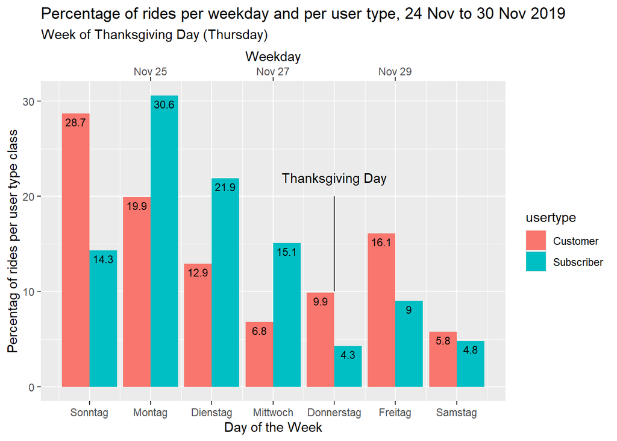

```r
df_v2 %>% mutate(weekday = wday(df_v2$start_time, label = TRUE )) %>%
  filter(between(date, as.Date('2019-11-24'), as.Date('2019-11-30'))) %>% group_by(usertype, date) %>%
  summarise(total = n()) %>% mutate(Percentage = round(total/sum(total)*100,1)) %>%
  ggplot(mapping = aes(x= date, y= Percentage, fill = usertype)) +
  geom_col(position = "dodge") + labs(x = "Day of the Week",
  y = "Percentag of rides per user type class",
  title= "Percentage of rides per weekday and per user type, 24 Nov to 30 Nov 2019",
  subtitle ="Week of Thanksgiving Day (Thursday)" ) +
  geom_text(aes(label= Percentage), vjust=1.5, size = 3,
            position = position_dodge(width = 0.9))+
  scale_x_date(sec.axis = sec_axis(~., name = "Weekday"),date_breaks = "1 day",
  date_labels = "%A" ) +
  annotate(geom = "segment", x = as.Date('2019-11-28'), y = 20, xend = as.Date('2019-11-28'), yend = 10)+
  annotate(geom = "Text", x = as.Date('2019-11-28'), y = 22, label = "Thanksgiving Day", hjust = "center")
```